# MovieLens_Project_Ram_Mishra

### Project - MovieLens Data Analysis

The GroupLens Research Project is a research group in the Department of Computer Science and Engineering at the University of Minnesota. The data is widely used for collaborative filtering and other filtering solutions. However, we will be using this data to act as a means to demonstrate our skill in using Python to “play” with data.

#### Domain

Internet and Entertainment

**Note that the project will need you to apply the concepts of groupby and merging extensively.**

#### ---------------------------------- Ram Mishra - ----------------------------

#### 1. Import the necessary packages - 2.5 marks

```python
import pandas as pd
import numpy as np
import matplotlib.pyplot as plt
import seaborn as sns
```

```python
sns.set(color_codes=True)
%matplotlib inline
```

#### 2. Read the 3 datasets into dataframes - 2.5 marks

```python
data=pd.read_csv("Data.csv")
item=pd.read_csv("item.csv")
user=pd.read_csv("user.csv")
moviedDf=data.merge(user,left_on='user id',right_on='user id',how='outer')
moviedDf=moviedDf.merge(item,left_on='movie id',right_on='movie id',how='outer')
```

#### 3. Apply info, shape, describe, and find the number of missing values in the data - 5 marks

```python
# Apply info
moviedDf.info()
```

```
<class 'pandas.core.frame.DataFrame'>
Int64Index: 100000 entries, 0 to 99999
Data columns (total 29 columns):
 #   Column        Non-Null Count   Dtype
---  ------        --------------   -----
 0   user id       100000 non-null  int64
 1   movie id      100000 non-null  int64
 2   rating        100000 non-null  int64
 3   timestamp     100000 non-null  int64
 4   age           100000 non-null  int64
 5   gender        100000 non-null  object
 6   occupation    100000 non-null  object
 7   zip code      100000 non-null  object
 8   movie title   99991 non-null   object
 9   release date  99991 non-null   object
```

[output cut: 21 more lines]

```python
# Apply shape
moviedDf.shape
```

```
(100000, 29)
```

```python
# Apply describe
moviedDf.describe().T
```

|  | count | mean | std | min | 25% | 50% | 75% | max |
| --- | --- | --- | --- | --- | --- | --- | --- | --- |
| user id | 100000.0 | 4.624848e+02 | 2.666144e+02 | 1.0 | 254.0 | 447.0 | 682.0 | 943.0 |
| movie id | 100000.0 | 4.255301e+02 | 3.307984e+02 | 1.0 | 175.0 | 322.0 | 631.0 | 1682.0 |
| rating | 100000.0 | 3.529860e+00 | 1.125674e+00 | 1.0 | 3.0 | 4.0 | 4.0 | 5.0 |
| timestamp | 100000.0 | 8.835289e+08 | 5.343856e+06 | 874724710.0 | 879448709.5 | 882826944.0 | 888259984.0 | 893286638.0 |
| age | 100000.0 | 3.296985e+01 | 1.156262e+01 | 7.0 | 24.0 | 30.0 | 40.0 | 73.0 |
| unknown | 99991.0 | 1.000090e-05 | 3.162420e-03 | 0.0 | 0.0 | 0.0 | 0.0 | 1.0 |
| Action | 99991.0 | 2.559130e-01 | 4.363754e-01 | 0.0 | 0.0 | 0.0 | 1.0 | 1.0 |
| Adventure | 99991.0 | 1.375424e-01 | 3.444208e-01 | 0.0 | 0.0 | 0.0 | 0.0 | 1.0 |
| Animation | 99991.0 | 3.605324e-02 | 1.864236e-01 | 0.0 | 0.0 | 0.0 | 0.0 | 1.0 |
| Childrens | 99991.0 | 7.182646e-02 | 2.582016e-01 | 0.0 | 0.0 | 0.0 | 0.0 | 1.0 |
| Comedy | 99991.0 | 2.983469e-01 | 4.575348e-01 | 0.0 | 0.0 | 0.0 | 1.0 | 1.0 |
| Crime | 99991.0 | 8.055725e-02 | 2.721553e-01 | 0.0 | 0.0 | 0.0 | 0.0 | 1.0 |
| Documentary | 99991.0 | 7.580682e-03 | 8.673691e-02 | 0.0 | 0.0 | 0.0 | 0.0 | 1.0 |
| Drama | 99991.0 | 3.989859e-01 | 4.896923e-01 | 0.0 | 0.0 | 0.0 | 1.0 | 1.0 |
| Fantasy | 99991.0 | 1.352122e-02 | 1.154925e-01 | 0.0 | 0.0 | 0.0 | 0.0 | 1.0 |
| Film-Noir | 99991.0 | 1.733156e-02 | 1.305042e-01 | 0.0 | 0.0 | 0.0 | 0.0 | 1.0 |
| Horror | 99991.0 | 5.317479e-02 | 2.243830e-01 | 0.0 | 0.0 | 0.0 | 0.0 | 1.0 |
| Musical | 99991.0 | 4.954446e-02 | 2.170029e-01 | 0.0 | 0.0 | 0.0 | 0.0 | 1.0 |
| Mystery | 99991.0 | 5.245472e-02 | 2.229433e-01 | 0.0 | 0.0 | 0.0 | 0.0 | 1.0 |
| Romance | 99991.0 | 1.946275e-01 | 3.959157e-01 | 0.0 | 0.0 | 0.0 | 0.0 | 1.0 |
| Sci-Fi | 99991.0 | 1.273115e-01 | 3.333232e-01 | 0.0 | 0.0 | 0.0 | 0.0 | 1.0 |
| Thriller | 99991.0 | 2.187397e-01 | 4.133937e-01 | 0.0 | 0.0 | 0.0 | 0.0 | 1.0 |
| War | 99991.0 | 9.398846e-02 | 2.918141e-01 | 0.0 | 0.0 | 0.0 | 0.0 | 1.0 |
| Western | 99991.0 | 1.854167e-02 | 1.349002e-01 | 0.0 | 0.0 | 0.0 | 0.0 | 1.0 |

```python
# Number of missing values
moviedDf.isnull().sum()
```

```
user id         0
movie id        0
rating          0
timestamp       0
age             0
gender          0
occupation      0
zip code        0
movie title     9
release date    9
unknown         9
Action          9
Adventure       9
Animation       9
Childrens       9
Comedy          9
Crime           9
Documentary     9
Drama           9
Fantasy         9
Film-Noir       9
Horror          9
Musical         9
Mystery         9
Romance         9
Sci-Fi          9
Thriller        9
War             9
Western         9
dtype: int64
```

#### 4. Find the number of movies per genre using the item data - 5 marks

```python
# use sum on the default axis
# Item.csv col
genre=['unknown', 'Action',
       'Adventure', 'Animation', 'Childrens', 'Comedy', 'Crime', 'Documentary',
       'Drama', 'Fantasy', 'Film-Noir', 'Horror', 'Musical', 'Mystery',
       'Romance', 'Sci-Fi', 'Thriller', 'War', 'Western']
item[genre].sum() # Item.csv data
```

```
unknown          1
Action         251
Adventure      135
Animation       42
Childrens      122
Comedy         505
Crime          109
Documentary     50
Drama          725
Fantasy         22
Film-Noir       24
Horror          92
Musical         56
Mystery         61
Romance        247
Sci-Fi         101
Thriller       251
War             71
Western         27
dtype: int64
```

#### 5. Find the movies that have more than one genre - 2.5 marks

```python
#hint: use sum on the axis = 1
item[item[genre].sum(axis=1)>1]
```

|  | movie id | movie title | release date | unknown | Action | Adventure | Animation | Childrens | Comedy | Crime | ... | Fantasy | Film-Noir | Horror | Musical | Mystery | Romance | Sci-Fi | Thriller | War | Western |
| --- | --- | --- | --- | --- | --- | --- | --- | --- | --- | --- | --- | --- | --- | --- | --- | --- | --- | --- | --- | --- | --- |
| 0 | 1 | Toy Story | 01-Jan-1995 | 0 | 0 | 0 | 1 | 1 | 1 | 0 | ... | 0 | 0 | 0 | 0 | 0 | 0 | 0 | 0 | 0 | 0 |
| 1 | 2 | GoldenEye | 01-Jan-1995 | 0 | 1 | 1 | 0 | 0 | 0 | 0 | ... | 0 | 0 | 0 | 0 | 0 | 0 | 0 | 1 | 0 | 0 |
| 3 | 4 | Get Shorty | 01-Jan-1995 | 0 | 1 | 0 | 0 | 0 | 1 | 0 | ... | 0 | 0 | 0 | 0 | 0 | 0 | 0 | 0 | 0 | 0 |
| 4 | 5 | Copycat | 01-Jan-1995 | 0 | 0 | 0 | 0 | 0 | 0 | 1 | ... | 0 | 0 | 0 | 0 | 0 | 0 | 0 | 1 | 0 | 0 |
| 6 | 7 | Twelve Monkeys | 01-Jan-1995 | 0 | 0 | 0 | 0 | 0 | 0 | 0 | ... | 0 | 0 | 0 | 0 | 0 | 0 | 1 | 0 | 0 | 0 |
| ... | ... | ... | ... | ... | ... | ... | ... | ... | ... | ... | ... | ... | ... | ... | ... | ... | ... | ... | ... | ... | ... |
| 1667 | 1669 | MURDER and murder | 20-Jun-1997 | 0 | 0 | 0 | 0 | 0 | 0 | 1 | ... | 0 | 0 | 0 | 0 | 1 | 0 | 0 | 0 | 0 | 0 |
| 1668 | 1670 | Tainted | 01-Feb-1998 | 0 | 0 | 0 | 0 | 0 | 1 | 0 | ... | 0 | 0 | 0 | 0 | 0 | 0 | 0 | 1 | 0 | 0 |
| 1671 | 1673 | Mirage | 01-Jan-1995 | 0 | 1 | 0 | 0 | 0 | 0 | 0 | ... | 0 | 0 | 0 | 0 | 0 | 0 | 0 | 1 | 0 | 0 |
| 1677 | 1679 | B. Monkey | 06-Feb-1998 | 0 | 0 | 0 | 0 | 0 | 0 | 0 | ... | 0 | 0 | 0 | 0 | 0 | 1 | 0 | 1 | 0 | 0 |
| 1678 | 1680 | Sliding Doors | 01-Jan-1998 | 0 | 0 | 0 | 0 | 0 | 0 | 0 | ... | 0 | 0 | 0 | 0 | 0 | 1 | 0 | 0 | 0 | 0 |

849 rows × 22 columns

#### 6. Drop the movie where the genre is unknown - 2.5 marks

```python
item.drop(item.index[item.unknown==1],inplace=True)
```

### 7. Univariate plots of columns: 'rating', 'Age', 'release year', 'Gender' and 'Occupation' - 10 marks

```python
# HINT: use distplot for age and countplot for gender,ratings,occupation.
# HINT: Please refer to the below snippet to understand how to get to release year from release date. You can use str.split()
# as depicted below
# Hint : Use displot without kde for release year or line plot showing year wise count.
```

```python
a = 'My*cat*is*brown'
print(a.split('*')[3])

#similarly, the release year needs to be taken out from release date

#also you can simply slice existing string to get the desired data, if we want to take out the colour of the cat

print(a[10:])
print(a[-5:])
```

```
brown
brown
brown
```

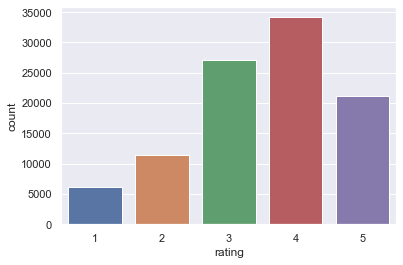

```python
# countplot for ratings
sns.countplot(x="rating",data=moviedDf);
```

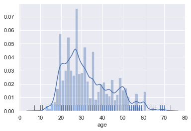

```python
# distplot for age
sns.distplot(moviedDf["age"],kde=True,rug=True, hist=True);
```

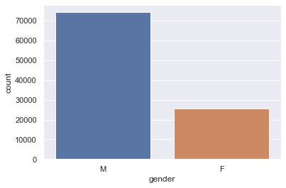

```python
# countplot for gender
sns.countplot(x="gender",data=moviedDf);
```

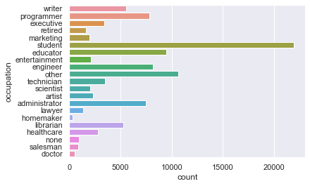

```python
# countplot for occupation
sns.countplot(y="occupation",data=moviedDf);
```

```python
# Year addibng column
moviedDf["release year"]=pd.to_datetime(moviedDf["release date"]).dt.year
```

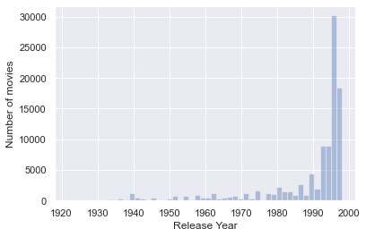

```python
# moviedDf.describe()
# Get the release year from release date
sns.distplot(pd.DatetimeIndex(moviedDf["release date"]).year,kde=False).set(xlabel="Release Year",ylabel="Number of movies");
```

### 8. Visualize how popularity of genres has changed over the years - 10 marks

Note that you need to use the number of releases in a year as a parameter of popularity of a genre

Hint

1: you need to reach to a data frame where the release year is the index and the genre is the column names (one cell shows the number of release in a year in one genre) or vice versa. Once that is achieved, you can either use univariate plots or can use the heatmap to visualise all the changes over the years in one go.

Hint 2: Use groupby on the relevant column and use sum() on the same to find out the nuumber of releases in a year/genre.

```python
yearlySummary=moviedDf.groupby("release year")[genre].sum()
```

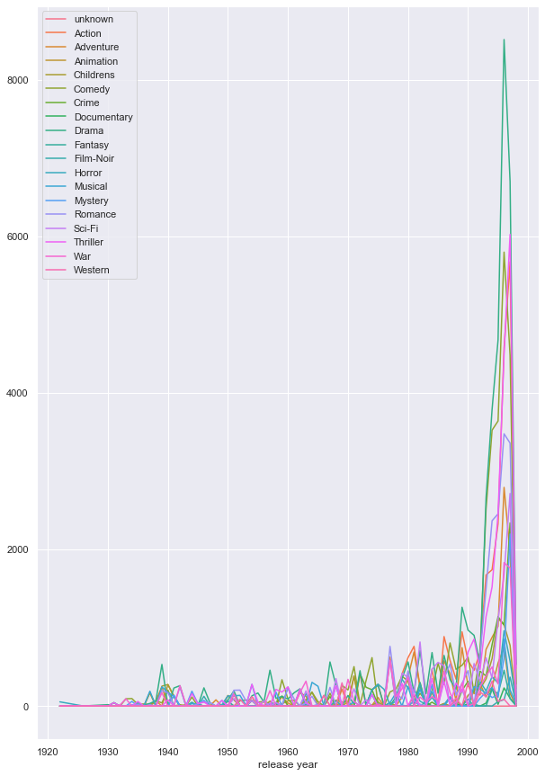

```python
plt.figure(figsize=(10,15))
sns.lineplot(data=yearlySummary,dashes=False);
```

Hint :

1. First find the movies that have more than 100 ratings(use merge, groupby and count). Extract the movie titles in a list.
2. Find the average rating of all the movies and sort them in the descending order. You will have to use the .merge() function to reach to a data set through which you can get the names and the average rating.
3. Use isin(list obtained from 1) to filter out the movies which have more than 100 ratings.

Note: This question will need you to research about groupby and apply your findings. You can find more on groupby on https://realpython.com/pandas-groupby/.

```python
# Top 25 movies
movie = moviedDf.groupby('movie title').agg({'rating': [np.size, np.mean]})
MoreThan100Rating = movie['rating']['size'] >= 100
movie[MoreThan100Rating].sort_values([('rating', 'size')], ascending=False)[:25]
```

| movie title | rating size | rating mean |
| --- | --- | --- |
| Star Wars | 583 | 4.358491 |
| Contact | 509 | 3.803536 |
| Fargo | 508 | 4.155512 |
| Return of the Jedi | 507 | 4.007890 |
| Liar Liar | 485 | 3.156701 |
| English Patient, The | 481 | 3.656965 |
| Scream | 478 | 3.441423 |
| Toy Story | 452 | 3.878319 |
| Air Force One | 431 | 3.631090 |
| Independence Day (ID4) | 429 | 3.438228 |
| Raiders of the Lost Ark | 420 | 4.252381 |
| Godfather, The | 413 | 4.283293 |
| Pulp Fiction | 394 | 4.060914 |
| Twelve Monkeys | 392 | 3.798469 |
| Silence of the Lambs, The | 390 | 4.289744 |
| Jerry Maguire | 384 | 3.710938 |
| Chasing Amy | 379 | 3.839050 |
| Rock, The | 378 | 3.693122 |
| Empire Strikes Back, The | 367 | 4.204360 |
| Star Trek: First Contact | 365 | 3.660274 |
| Back to the Future | 350 | 3.834286 |
| Titanic | 350 | 4.245714 |
| Mission: Impossible | 344 | 3.313953 |
| Fugitive, The | 336 | 4.044643 |
| Indiana Jones and the Last Crusade | 331 | 3.930514 |

### 10. See gender distribution across different genres check for the validity of the below statements - 10 marks

- Men watch more drama than women
- Women watch more Sci-Fi than men
- Men watch more Romance than women
1. There is no need to conduct statistical tests around this. Just compare the percentages and comment on the validity of the above statements.
2. you might want ot use the .sum(), .div() function here.
3. Use number of ratings to validate the numbers. For example, if out of 4000 ratings received by women, 3000 are for drama, we will assume that 75% of the women watch drama.

#### Conclusion:

```python
moviedDf[(moviedDf['gender']=='M')].count()
```

```
user id         74260
movie id        74260
rating          74260
timestamp       74260
age             74260
gender          74260
occupation      74260
zip code        74260
movie title     74253
release date    74253
unknown         74253
Action          74253
Adventure       74253
Animation       74253
Childrens       74253
Comedy          74253
Crime           74253
Documentary     74253
Drama           74253
Fantasy         74253
Film-Noir       74253
Horror          74253
Musical         74253
Mystery         74253
Romance         74253
Sci-Fi          74253
Thriller        74253
War             74253
Western         74253
release year    74253
dtype: int64
```

```python
moviedDf[(moviedDf['gender']=='F')].count()
```

```
user id         25740
movie id        25740
rating          25740
timestamp       25740
age             25740
gender          25740
occupation      25740
zip code        25740
movie title     25738
release date    25738
unknown         25738
Action          25738
Adventure       25738
Animation       25738
Childrens       25738
Comedy          25738
Crime           25738
Documentary     25738
Drama           25738
Fantasy         25738
Film-Noir       25738
Horror          25738
Musical         25738
Mystery         25738
Romance         25738
Sci-Fi          25738
Thriller        25738
War             25738
Western         25738
release year    25738
dtype: int64
```

```python
#print(moviedata[(moviedata['gender']=='M') & (moviedata['Drama']==1)].count())

print("Men watch more drama than women : False statement ")
print( "Women watch more Sci-Fi than men : false statement ")
print("Men watch more Romance than women: false statement")
```

```
Men watch more drama than women : False statement
Women watch more Sci-Fi than men : false statement
Men watch more Romance than women: false statement
```